```python
%%javascript
IPython.OutputArea.prototype._should_scroll = function(lines) {
    return false;
}
```

```python
# to load images for this tutorial
from IPython.display import Image
import os
path = os.getcwd()
```

# Post Goals:

1. Provide an Introduction to Testing for Normality.
2. Demonstrate how to test for Normality for **None or One Independent Variable** Using SPSS, Skewness, Kurtosis, and Z-scores.

# Post Overview.

1. Introduction to Testing for Normality.
2. Testing for Normality Using Skewness, Kurtosis, and Z-scores for None or One Independent Variable.
3. Demonstrate how to test for Normality Using SPSS, Skewness, Kurtosis, and Z-scores.

# Introduction to Testing for Normality.

#### Intro to Testing for Normaility

- In statistics, testing for normality is used to:
  - determine if a data set is modeled by a normal distribution.
  - compute how likely it is for a random variable underlying the data set to be normally distributed.
  - Testing for Normality is often used when analyzing the difference between groups using parametric tests.
  - A common assumption is that the dependent variable is approximately normally distributed for each group of the independent variable.

#### Normal Distribution

- A normal distribution describes a distribution of data that resembles a bell shaped symmetrical curve, where half of the data falls before and after the mean.
- In a normal distribution, the mean, median and mode are generally equal.
- The total area under the curve is `1`.
- A normal distribution is part of probability theory, which is a type of continuous probability distribution for a real-value random variable.
- The general form of its probability density function: \[f(x) = {\frac{1}{\sigma \sqrt{2 \pi}}e^{-\frac{1}{2}(\frac{x - \mu}{\sigma})^{2}}}\]
  - where **\(\mu \)** is the mean.
  - where **\(\sigma \)** is the standard deviation.
  - where **\(\sigma^{2} \)** is the variance of the distribution.
- A percentage of the data falls within a certain number of standard deviations from the mean, as illustrated in Standard Normal Distribution Curve.
- Besides the percentages, many scores are derived from the normal distribution, such as percentile ranks, normal curve equivalents, and most commonly, **t-scores** and **z-scores**.

#### Numeric and Graphical Methods of assessment for Normality

| Numerical methods | Graphical methods |
| --- | --- |
| Advantage: allows one to make an objective judgement of normality. | Advantage: allows one to make a judgement to assess whether the data is normaly distributed. |
| Disadvantage: May not detect violation of normality in small sample sizes. | Disadvantage: Inspecting graphs/plots comes at the expense of objectivity. |
| Disadvantage: Overly sensitive to large sample sizes, as small deviations from normality are detected. | Methods include (but not limited to): Histographs, Normal Q-Q plot. |
| Disadvantage: This method alone doesn't let you explore the data as graphical methods would. |  |
| Methods include (but not limited to): Skewness/Kurtosis, and Shapiro-Wilk Test. |  |

#### Z-Scores and Normal Distribution

- A z-score (standard score) represents the number of standard deviations a given data value "x" falls from the mean.
- The Z-score is calculated by subtracting the data value by the mean and dividing that by the population standard deviation:  
  \[z = {\frac{x - \mu}{\sigma}}\]
  - where **x** is the value being examined.
  - where **\(\mu \)** is the population mean.
  - where **\(\sigma \)** is the population standard deviation.
- The z-score provides the position of a given value along a standard normal distribution.
- If the z-score is negative, it is to the left of the mean.
- The area under the curve is called the area percentage.
- The Area percentage is the proportion or probabilities between two points along the standard normal distribution.

#### Skewness, Kurtosis and the Normal Distribution

- The Normal Distribution Curve can also be described by two measures, its **Skewness** and **Kurtosis**.
- Skewness and kurtosis are used to test for normality.

**Skewness:**

- is a measure of the asymmetry of the probability distribution of a random variable about its mean.
- A normal distribution is symmetrical around the mean, and Skewness is `0`.
- Skewness can be positive, negative, zero, and undefined.
- For a univariate dataset, the formula for skewness is:  
  \[\tilde \mu_{3} = {\frac{\Sigma_{i=1}^{N}(x_{i} - \bar x)}{(N - 1)\sigma^{3}} } \]
  - where **\(\tilde \mu_{3} \)** is skewness.
  - where **N** number of variables in the distribution.
  - where **\(X_{i} \)** is the random variable.
  - where **\(\bar X \)** is the mean of the distribution.
  - where **\(\sigma \)** is the population standard deviation.
- Interpretation of skewness:
  - If **\(\tilde \mu_{3} \) < -1** or **\(\tilde \mu_{3} \) > 1**, then the distribution is highly skewed.
  - If **\(\tilde \mu_{3} \) is between `[-1, -0.5]` or between `[0.5, 1]`** the distribution is moderately skewed.
  - If **\(\tilde \mu_{3} \) is between `[-0.5, 0.5]`** the distribution approximately symmetric.

**Kurtosis:**

- is a measure of the "tailedness" of the probability distribution of a real-valued random variable.
- is a measure of whether the data are heavy-tailed or light-tailed relative to a normal distribution.
- Kurtosis also tells you the height and sharpness of the central peak, relative to the standard bell curve.
- Data sets with heavy tails have high kurtosis.
- Data sets with thin tails have low kurtosis.
- Kurtosis describes the shape of a probability distribution at the tail ends.
- The formula for kurtosis is:  
  \[Kurtosis = {\frac{\Sigma_{i=1}^{N}\frac{(x_{i} - \bar x)}{N}} {\sigma^{4}} } \]
  - where **\(\bar X \)** is the mean of the distribution.
  - where **\(\sigma \)** is the population standard deviation.
  - where **N** is the sample size.
- Interpretation of kurtosis:
  - The standard normal distribution has a **Kurtosis = `3`** and is called **Mesokurtic**.
  - **Kurtosis > `3`** is called **Leptokurtic**, and describes a curve with heavy tails.
  - **Kurtosis < `0`** is called **Platykurtic**, and describes a curve with thin tails.

  .

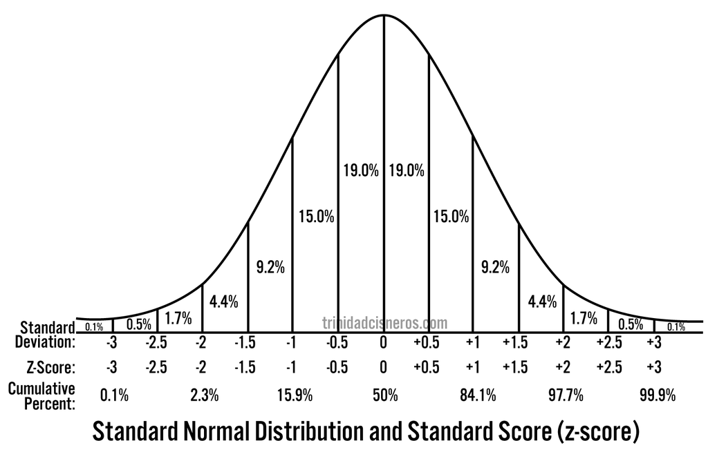

```python
img = os.path.join(path, 'static/images/spss0.png')
Image(filename=img, width=700)
```

# Testing for Normality Using Skewness, Kurtosis, and Z-scores for None or One Independent Variable.

#### The following method determines how the data differs from a normal distribution, and if the data is normally distributed or not.

1. Calcualte the z-score for skewness:  
   \[z = {\frac{Skewness}{Std. Error} } \]
2. Calcualte the z-score for kurtosis:  
   \[z = {\frac{Kurtosis}{Std. Error} } \]
3. Select the Level of Significance, which refers to the degres of significance in which we accept or reject the null hypothesis. The level of significance is usually denoted α. In this example, we use `0.01`.
4. Find the Z-score for the level of significance. In this case α= 0.01 has a z-score of ±2.58.
5. Compare Z-score for skewness and kurtosis to z-score for 0.01.

**Interpretation**

- If the z-score for skewness is within ±2.58, then data is nomrally distributed.
- If the z-score for skewness is not within the z-score for the α, then it is not normally distributed because the distribution is skewed.
- If the z-score for kurtosis is not within the z-score for the α, then it is not normally distributed because the distribution is kurtosed.

# Demonstrate how to test for Normality Using SPSS, Skewness, Kurtosis, and Z-scores.

#### Steps

1. Set up your data in SPSS.
2. Carry out procedure to get Skewness and Kurtosis from SPSS.
3. Calculate z-score for Skewness and Kurtosis.
4. Compare value to z-score for the selected level of significance α.

### Step 1: Data Set-Up

[figure not shown]

```python
img = os.path.join(path, 'static/images/spss1.png')
Image(filename=img, width=600)
```

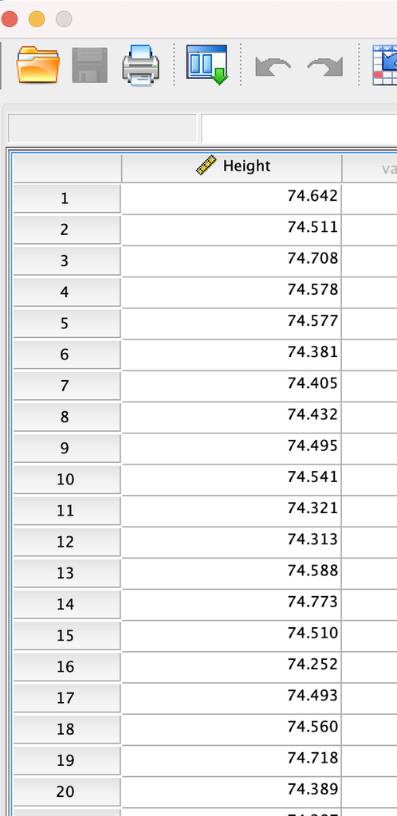

```python
img = os.path.join(path, 'static/images/spss2.png')
Image(filename=img, width=150)
```

### Step 2: Carry out procedure to get Skewness and Kurtosis from SPSS

- From main menu `Analyze > Descriptive Statistics > Explore`
- In `Explore dialogue box`, transfer dependent variable to `Dependent List`.
- Click `Plots` and `Explore: Plots Dialogue Box` will be presented
- `Explore: Plots Dialogue Box` select `None` in `Boxplots` area.
- `Explore: Plots Dialogue Box` uncheck `Stem-and-leaf` in the `Descriptive` area.
- `Explore: Plots Dialogue Box` check `Histogram` in the `Descriptive` area.
- `Explore: Plots Dialogue Box` check the `Normality plots with tests`.
- Click `Continue` button in the `Explore dialogue box`.
- Click `OK` button to generate the output.

**Results:**

- `Skewness` = 0.051
- `Kurtosis` = -0.150

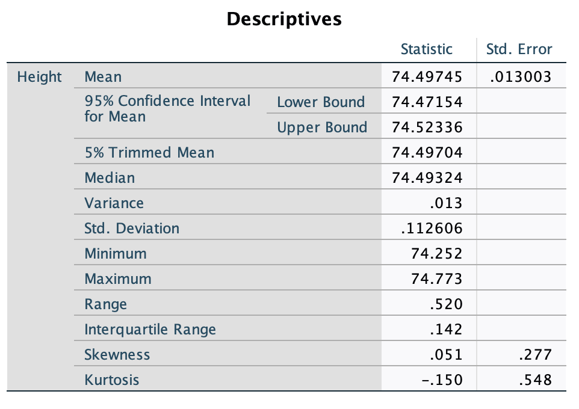

```python
img = os.path.join(path, 'static/images/spss3.png')
Image(filename=img, width=550)
```